[figure not shown]

# Assessing Medicare Payouts

Last week President Donald Trump released his budget proposal for the federal government for the coming year. His initial proposal includes a considerable cut, USD 451 billion and USD 920 billion, to Medicare and Medicaid respectively, over the next 10 years. Medicare is estimated to provide health insurance to over 60 million Americans, most of who are over the age of 65. Roughly 14% of the federal budget in FY18 was spent on Medicare, which amounts to approximately USD 582 billion.

As the medical industry weighs the future of medical insurance in the US, it will be pertinent to identify revenue streams that are buoyed by national health insurance programs such as Medicare and Medicaid and prepare their business strategy for budget cuts. The following project ranks total annual, national Medicare payouts by physician practice type for the year 2016.

### Data

The data is a CSV file from Centers for Medicare and Medicaid Services (CMS). Each instance is the annual aggregate data for a physician who charged Medicare for the year 2016. The original data includes numerous variables describing the physician, as well as variables detailing their financial interaction with Medicare (67 columns in total). I reduced the dimensions by deleting columns I would not be using in my analysis. I used the following columns: Physician ID, Physician practice type (type of medicine), and Total Payout (made to that physician by Medicare) in 2016. The image below is a sample of what the data looks like as my Map Reduce program reads it in.

Link to the data: https://www.kaggle.com/cms/medicare-physician-other-supplier-npi-aggregates#medicare-physician-and-other-supplier-national-provider-identifier-npi-aggregate-report-calendar-year-2016.csv

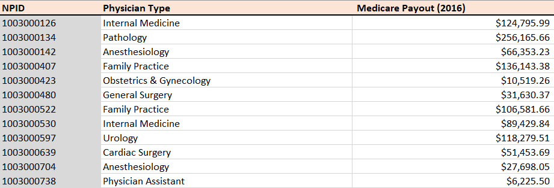

### MapReduce Code

```python
%%file IA_BigData_Part3.py
import datetime
from mrjob.job import MRJob
from mrjob.step import MRStep



class Rank_P_type(MRJob):

    # Define steps for mapper and reducers
    def steps(self):
          return  [
              MRStep(mapper = self.mapper_choose,
                     reducer = self.reducer_agg),
              MRStep(reducer = self.reducer_sort)]

    #Read in data line by line and return Physician type and total payout as a float
    def mapper_choose(self,_,line):
        (NPID, P_type, tot_pay) = line.split(',')
        yield P_type, float(tot_pay)

    # Group each instance by physican type and turn the grouping of instances into a list. Perform calculations for each physican
    # type - total Medicare payout, number of physicians, average Medicare payout, min and max Medicare payout
    def reducer_agg(self, P_type, total):
        for i in total:
            if P_type == P_type:
                p_list = list(total)
                yield None, (round(sum(p_list)), P_type, len(p_list), round(sum(p_list)/len(p_list)), round(min(p_list)), round(max(p_list)))

    # Reads in key, value tuple from the previous reducer and unpacks it. Sorts in descending order by the total Medicare payout
    def reducer_sort(self, _, value):
        for tot, P_type, count, avg_p, min_p, max_p in sorted(value, reverse=True):
            yield (P_type, count), ("$"+format(tot), "$"+format(min_p), "$"+format(avg_p), "$"+format(max_p))



if __name__ == '__main__':
    Rank_P_type.run()
```

```
Overwriting IA_BigData_Part3.py
```

My code contains one mapper and two reducers, which is not a very extensive MapReduce program, but the project was for demonstration purposes.

```python
!python IA_BigData_Part3.py provider_type.csv
```

[output not shown]

[output cut: 37 more lines]

```
["Speech Language Pathologist",822]	["$22528771","$827","$27407","$330358"]
["Registered Dietitian or Nutrition Professional",1999]	["$14882955","$288","$7445","$186979"]
["Preventive Medicine",336]	["$13997153","$65","$41658","$2548056"]
["Geriatric Psychiatry",201]	["$13927758","$1192","$69292","$573385"]
["Maxillofacial Surgery",942]	["$12802733","$287","$13591","$783284"]
["Peripheral Vascular Disease",58]	["$11676002","$1427","$201310","$822854"]
["Neuropsychiatry",119]	["$8751679","$913","$73544","$849054"]
["Addiction Medicine",167]	["$7076521","$61","$42374","$489269"]
["Public Health or Welfare Agency",249]	["$5395169","$435","$21667","$1598538"]
["Slide Preparation Facility",22]	["$3904914","$3623","$177496","$1116594"]
["Certified Nurse Midwife",863]	["$2683201","$49","$3109","$111485"]
["Mammography Center",17]	["$2038098","$1908","$119888","$922013"]
["Unknown Supplier\/Provider Specialty",11]	["$290790","$3069","$26435","$64395"]
["Dentist",1]	["$13820","$13820","$13820","$13820"]
["Hospitalist",1]	["$13751","$13751","$13751","$13751"]
```

[output not shown]

### MapReduce Output

The output is formatted as follows:

(Physician Type, Number of Physicians), (Total Medicare Payout, Min Payout Made, Average Payout Made, Max Payout Made)

They are ordered descending by Total Medicare Payout.

### Spark Code

```python
%%file Medicare_spark.py
import datetime
from pyspark import SparkConf, SparkContext

start_time = datetime.datetime.now()

conf = SparkConf().setMaster("local").setAppName("Medicare")
sc = SparkContext(conf = conf)

# Function to parse lines of code as they are read into the RDD
def parseLine(line):
    fields = line.split(',')
    P_type = fields[1]
    total = float(fields[2])
    return (P_type, total)

# Source data and read into the RDD
lines = sc.textFile("file:///sparkcourse/Github/provider_type.csv")
rdd = lines.map(parseLine)

#calculate the toatal number of physicians by physican type and sum up the total Medicare payouts made
totals = rdd.mapValues(lambda x: (x, 1)).reduceByKey(lambda x, y: (round(x[0] + y[0]), x[1] + y[1]))#.mapValues(lambda x, y: x/y)

#Find the max Medicare payout made by physican type
max_vals = rdd.reduceByKey(lambda x, y: x if x > y else y)

#Find the min Medicare payout made by physican type
min_vals = rdd.reduceByKey(lambda x, y: x if x < y else y)

#Join the min and max
rdd_temp = min_vals.join(max_vals)

#Join the min and max with the other RDD
rdd_final = totals.join(rdd_temp)

#rdd_final = rdd_temp2.map(lambda x, y : x[1], (x[0], y[0], y[1]))

results = rdd_final.collect()
for i in results:
    print(i)

stop_time = datetime.datetime.now()
print("Time required to execute:", stop_time - start_time)
```

```
Overwriting Medicare_spark.py
```

```python
!spark-submit Medicare_spark.py
```

```
('Internal Medicine', ((9219758716, 100296), (42.37, 6135320.16)))
('Pathology', ((966552454, 11628), (168.83, 9328392.27)))
('Anesthesiology', ((1643682400, 37704), (369.72, 8248407.92)))
('Urology', ((1716584596, 8958), (353.01, 2060544.85)))
('Cardiac Surgery', ((238963604, 1441), (478.29, 3190804.42)))
('Dermatology', ((2574026570, 11375), (0.0, 4705060.2)))
('Certified Registered Nurse Anesthetist (CRNA)', ((898453475, 41811), (524.19, 305660.96)))
('Physical Medicine and Rehabilitation', ((914511369, 7732), (0.0, 3515593.65)))
('Radiation Oncology', ((1470432225, 4456), (485.84, 8813584.71)))
('Infectious Disease', ((591284013, 5535), (156.56, 6819006.45)))
('Licensed Clinical Social Worker', ((293105208, 18709), (1.08, 615529.82)))
('Certified Clinical Nurse Specialist', ((50773272, 2075), (29.4, 394963.68)))
('Diagnostic Radiology', ((3892969212, 29714), (77.96, 6218693.52)))
('Rheumatology', ((1794000555, 4514), (299.97, 7084092.01)))
('General Practice', ((316366509, 5544), (60.37, 3366622.5)))
('Neurology', ((1415262039, 13919), (374.31, 14304835.75)))
('Emergency Medicine', ((2439047048, 42363), (38.99, 2390427.71)))
('Hand Surgery', ((157034409, 1383), (873.93, 602535.72)))
('Ophthalmology', ((6684020054, 17696), (102.59, 11518827.42)))
('Nurse Practitioner', ((2372160530, 98002), (0.0, 2059451.16)))
('Osteopathic Manipulative Medicine', ((38972156, 629), (206.82, 1780255.04)))
('Interventional Cardiology', ((610218087, 2567), (663.22, 4572295.12)))
('Audiologist', ((47287414, 6189), (0.0, 1966683.13)))
('Geriatric Medicine', ((159800987, 1851), (203.24, 719652.95)))
('Neurosurgery', ((616033567, 4615), (83.84, 1651197.71)))
('Pain Management', ((340863346, 2052), (279.85, 4139878.01)))
('Optometry', ((825273800, 29067), (33.15, 2495699.53)))
('Hematology-Oncology', ((5066844327, 8140), (355.92, 8224843.12)))
('All Other Suppliers', ((324576165, 792), (386.98, 45826480.29)))
('Ambulatory Surgical Center', ((3446364393, 5012), (1079.92, 13134974.46)))
('Nuclear Medicine', ((84803174, 564), (334.46, 2040440.75)))
('Allergy/ Immunology', ((266326050, 3362), (64.86, 4736429.52)))
('Occupational Therapist in Private Practice', ((158791379, 4859), (522.69, 681193.06)))
('Interventional Radiology', ((284177773, 1485), (194.49, 5606398.36)))
('Hematology', ((182292229, 708), (980.38, 6648914.94)))
('Speech Language Pathologist', ((22533418, 823), (826.96, 330357.81)))
('Portable X-Ray Supplier', ((228151853, 309), (1573.8, 83635303.31)))
('Surgical Oncology', ((65988961, 904), (1053.12, 2269487.02)))
('Interventional Pain Management', ((366209217, 1649), (1289.41, 2104934.61)))
('Public Health or Welfare Agency', ((5407725, 250), (435.2, 1598538.04)))
```

[output cut: 37 more lines]

```
('Anesthesiology Assistant', ((26765251, 1818), (704.38, 72274.33)))
('Oral Surgery (Dentists only)', ((29256612, 1418), (310.51, 2073744.59)))
('Maxillofacial Surgery', ((12808445, 943), (287.39, 783284.29)))
('Colorectal Surgery (Proctology)', ((127105582, 1428), (749.84, 1004617.33)))
('Geriatric Psychiatry', ((13939246, 202), (1192.15, 573385.27)))
('Mammography Center', ((2124188, 18), (1908.06, 922012.59)))
('Preventive Medicine', ((14015610, 337), (64.68, 2548056.25)))
('Clinic or Group Practice', ((61957928, 440), (57.54, 16668091.82)))
('Neuropsychiatry', ((8811915, 120), (912.92, 849053.68)))
('Gynecological Oncology', ((110267710, 949), (783.28, 2257746.18)))
('Undefined Physician type', ((35443231, 287), (441.23, 1223862.23)))
('Radiation Therapy Center', ((53872847, 46), (17850.62, 7248542.25)))
('Unknown Supplier/Provider Specialty', ((320351, 12), (3069.31, 64395.1)))
('Dentist', ((45327, 2), (13819.98, 31506.78)))
Time required to execute: 0:00:18.475349
```

```
20/02/22 23:25:33 WARN NativeCodeLoader: Unable to load native-hadoop library for your platform... using builtin-java classes where applicable
```

### Analysis

Additional analysis could use the same data source to break down the analysis from a national level to a state and zip code level. This could allow various businesses in the medical industry to prepare for regional changes in revenue as the budget cuts are enacted.

### Conclusion

While MapReduce is largely outdated, it was valuable to learn the methodology inside-out by writing my own program to address a business problem. Additionally, this was my first object-oriented programming experience. Spark is considered an upgrade over MapReduce for reasons such as it's use of functional coding and it's capability of handling both batch processess and live streaming processes.

As evidenced above, Spark essentially automates the key, value pairing system and allows for functional coding. This eliminates the headaches of laying out the Map and Reduce step by step, and tuple unpacking. After exhaustive research into how to unpack ‘generator’ tuples in MapReduce I discovered that it was easier for me to use the data by turning the tuples into a list, as I do in my first reducer. This allowed me to freely index the data for each physician type and execute the calculations for my analysis. But this was essentially a work-around that I did not have to deal with in Spark.